# [eb4] Analyses

Egor Ananyev

2020-10-22

# 1 Data input and parsing

```r
options(width=100)
out=F
library(plyr)
library(dplyr)
library(ggplot2)
library(lme4)
library(lmerTest)
library(reshape)
library(R.utils)
computer = 'acer'  # 'shocky', 'station3', 'acer' are all possible options
if(computer=='acer'){
  cloud_dir = 'C:/gd/'
  prog_dir = 'C:/Users/egora/Prog/'
}
if(computer=='shocky'){
  cloud_dir = 'C:/gd/'
  prog_dir = 'C:/Users/Egor/Prog/'
}
if(computer=='station3'){
  cloud_dir = '/home/station3/Desktop/Egor/'
  prog_dir = cloud_dir
}
if(computer == 'toshi') {
  cloud_dir = 'C:/Users/Egor/Google Drive/'
  prog_dir = 'C:/Users/Egor/Prog/'
}
sourceDirectory(paste0(prog_dir, 'eb/an/funs_an'))
source(paste0(cloud_dir, 'Prog/R/myFunctions/pvalfn.R'))
ds = read.csv(paste0(prog_dir, 'eb/an/consolidated/ds4.csv'))
dsa = read.csv(paste0(prog_dir, 'eb/an/consolidated/dsa4.csv'))
# Reordering levels of Condition variable, such that No Blink condition is the reference:
ds$Cond = factor(ds$Cond, c('NoBlink','Artificial','Prompted'))
ds$CondFull = factor(ds$CondFull, c('No Blink','Artificial Blink','Prompted Blink'))
cue_valid_name = 'Cue Validity'
```

Condition order variable:

```r
sumss_cond = ddply(ds[ds$block_order==1,], .(subj, Cond, block_time), summarise, cond_order = 0)
sumss_cond = sumss_cond %>% group_by(subj) %>% mutate(cond_order=order(order(block_time)))
# ... I've no idea why I need to double-wrap order(), but I have to to make it work right.
head(sumss_cond, 12)
```

| subj | Cond | block_time | cond_order |
| --- | --- | --- | --- |
| 2 | NoBlink | 1236 | 3 |
| 2 | Artificial | 1211 | 1 |
| 2 | Prompted | 1222 | 2 |
| 3 | NoBlink | 1318 | 2 |
| 3 | Artificial | 1333 | 3 |
| 3 | Prompted | 1303 | 1 |
| 4 | NoBlink | 1418 | 2 |
| 4 | Artificial | 1358 | 1 |
| 4 | Prompted | 1435 | 3 |
| 5 | NoBlink | 1519 | 2 |
| 5 | Artificial | 1533 | 3 |
| 5 | Prompted | 1459 | 1 |

```r
# since we're not merging by block time, dropping it first:
sumss_cond = subset(sumss_cond, select=-c(block_time))
ds = merge(ds, sumss_cond, by=c('subj', 'Cond'))
dsa = merge(dsa, sumss_cond, by=c('subj', 'Cond'))
```

# 2 Cueing

## 2.1 Boxplots

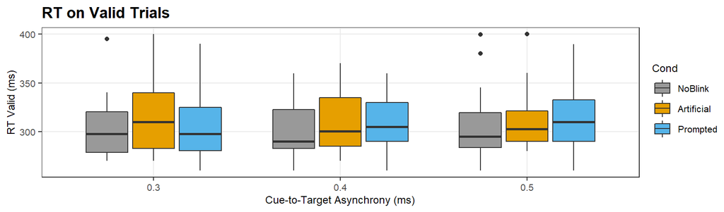

```r
ss_corr = ds[ds$corr_resp==1, ]
ctoa_valid = ddply(ss_corr[ss_corr$CueValid=='Valid',], .(targ_soa, Cond, subj), summarise,
                   RT=median(RT))
plot_box_ctoa(ctoa_valid, 'Cue-to-Target Asynchrony (ms)', 'RT Valid (ms)',
              'RT on Valid Trials', out, 'targ_soa', eb='eb3')
```

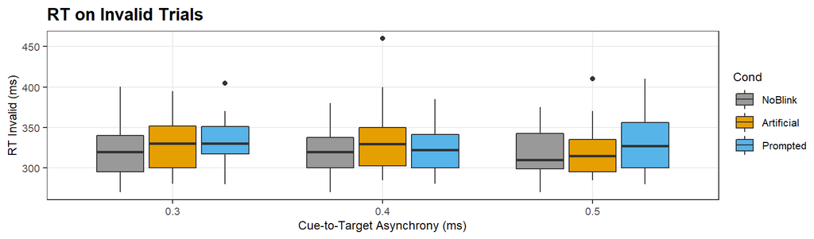

```r
ctoa_invalid = ddply(ss_corr[ss_corr$CueValid=='Invalid',], .(targ_soa, Cond, subj), summarise,
                  RT=median(RT))
plot_box_ctoa(ctoa_invalid, 'Cue-to-Target Asynchrony (ms)', 'RT Invalid (ms)',
              'RT on Invalid Trials', out, 'targ_soa', eb='eb3')
```

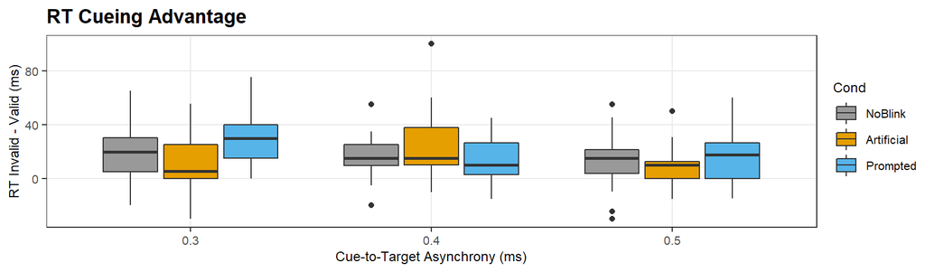

```r
ctoa_adv = merge(ctoa_valid, ctoa_invalid, by=c('targ_soa', 'Cond', 'subj'))
ctoa_adv$RT = ctoa_adv$RT.y - ctoa_adv$RT.x  # Invalid - Valid RT
plot_box_ctoa(ctoa_adv, 'Cue-to-Target Asynchrony (ms)', 'RT Invalid - Valid (ms)',
              'RT Cueing Advantage', out, 'targ_soa', eb='eb3')
```

## 2.2 Analyses

It makes no sense to center cue validity.

A potential rationale for centering validity is to look at the rest of the effects with respect to a “neutral” cue. But this goes against the usefulness of centering: it is meant to focus the effects on *meaningful* levels of a variable, whereas no neutral cue exists in the data. A more logical “reference” level for the valid cue is the invalid one.

For the CTOA, instead of centering on the mean, I went for centering on the shortest asynchrony, and scaling the data such that a unit of 1 is the step from the shortest to longest asynchrony. This way, an effect of CTOA would indicate the change in RT when the asynchrony changes from shortest to longest.

```r
ds_rt = ss_corr
ds_rt$ctoa_0 = (ds_rt$targ_soa - 0.3) * 5  # [0.3, 0.4, 0.5] -> [0, 0.1, 0.2] -> [0, 0.5, 1]
# ds_rt$ctoa_c = (ds_rt$targ_soa - 0.4) * 10  # to turn into [-1, 0, 1]
# ds_rt$cue_valid_c = ds_ans$cue_valid * 2 - 1  # to turn [0, 1] into [-1, 1]
```

```r
print(lmerfn(lmer(RT ~ cue_valid * Cond * ctoa_0 + block + (1|subj), data = ds_rt)))
```

```
##                                    estm    se       df   tVal  pVal star num
## (Intercept)                     332.770 6.790   37.271 49.010 0.000  ***   0
## cue_valid                       -17.556 3.322 8910.036 -5.286 0.000   **   1
## CondArtificial                   11.997 4.127 8910.154  2.907 0.004    *   2
## CondPrompted                      7.957 4.114 8910.099  1.934 0.053    ~   3
## ctoa_0                           -3.629 4.488 8910.185 -0.809 0.419        4
## block                            -3.973 0.654 8910.186 -6.078 0.000   **   5
## cue_valid:CondArtificial          4.375 4.753 8910.061  0.921 0.357        6
## cue_valid:CondPrompted           -4.680 4.738 8910.048 -0.988 0.323        7
## cue_valid:ctoa_0                  5.550 5.170 8910.047  1.073 0.283        8
## CondArtificial:ctoa_0            -2.403 6.394 8910.208 -0.376 0.707        9
## CondPrompted:ctoa_0               5.280 6.386 8910.162  0.827 0.408       10
## cue_valid:CondArtificial:ctoa_0  -8.142 7.361 8910.043 -1.106 0.269       11
## cue_valid:CondPrompted:ctoa_0     2.093 7.357 8910.075  0.285 0.776       12
```

```r
# print(anova(lmer(RT ~ cue_valid * Cond * ctoa_0 + (1|subj), data = ds_rt)))
```

```r
ds_rt_pb = ds_rt
ds_rt_pb$Cond = factor(ds_rt_pb$Cond, c('Prompted','Artificial','NoBlink'))
print(lmerfn(lmer(RT ~ cue_valid * Cond * ctoa_0 + block + (1|subj), data = ds_rt_pb)))
```

```
##                                    estm    se       df   tVal  pVal star num
## (Intercept)                     340.726 6.811   37.733 50.027 0.000  ***   0
## cue_valid                       -22.237 3.379 8910.057 -6.581 0.000   **   1
## CondArtificial                    4.041 4.162 8910.183  0.971 0.332        2
## CondNoBlink                      -7.957 4.114 8910.099 -1.934 0.053    ~   3
## ctoa_0                            1.651 4.545 8910.068  0.363 0.716        4
## block                            -3.973 0.654 8910.186 -6.078 0.000   **   5
## cue_valid:CondArtificial          9.056 4.792 8910.046  1.890 0.059        6
## cue_valid:CondNoBlink             4.680 4.738 8910.048  0.988 0.323        7
## cue_valid:ctoa_0                  7.643 5.234 8910.082  1.460 0.144        8
## CondArtificial:ctoa_0            -7.683 6.433 8910.081 -1.194 0.232        9
## CondNoBlink:ctoa_0               -5.280 6.386 8910.162 -0.827 0.408       10
## cue_valid:CondArtificial:ctoa_0 -10.236 7.406 8910.046 -1.382 0.167       11
## cue_valid:CondNoBlink:ctoa_0     -2.093 7.357 8910.075 -0.285 0.776       12
```

## 2.3 Afo/ cond & block order

Looking at the effect of the condition order only:

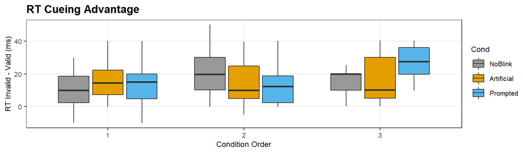

```r
ctoa_valid = ddply(ss_corr[ss_corr$CueValid=='Valid',], .(cond_order, Cond, subj),
                   summarise, RT=median(RT))
ctoa_invalid = ddply(ss_corr[ss_corr$CueValid=='Invalid',], .(cond_order, Cond, subj),
                     summarise, RT=median(RT))
ctoa_adv = merge(ctoa_valid, ctoa_invalid, by=c('cond_order', 'Cond', 'subj'))
ctoa_adv$RT = ctoa_adv$RT.y - ctoa_adv$RT.x  # Invalid - Valid RT
plot_box_ctoa(ctoa_adv, 'Condition Order', 'RT Invalid - Valid (ms)', 'RT Cueing Advantage', out,
              'cond_order', eb='eb3')
```

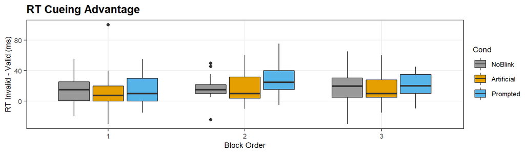

```r
ctoa_valid = ddply(ss_corr[ss_corr$CueValid=='Valid',], .(block_order, Cond, subj),
                   summarise, RT=median(RT))
ctoa_invalid = ddply(ss_corr[ss_corr$CueValid=='Invalid',], .(block_order, Cond, subj),
                     summarise, RT=median(RT))
ctoa_adv = merge(ctoa_valid, ctoa_invalid, by=c('block_order', 'Cond', 'subj'))
ctoa_adv$RT = ctoa_adv$RT.y - ctoa_adv$RT.x  # Invalid - Valid RT
plot_box_ctoa(ctoa_adv, 'Block Order', 'RT Invalid - Valid (ms)', 'RT Cueing Advantage', out,
              'block_order', eb='eb3')
```

Not so much of an effect of the block order, it seems.

Looking at both blocks and conditions:

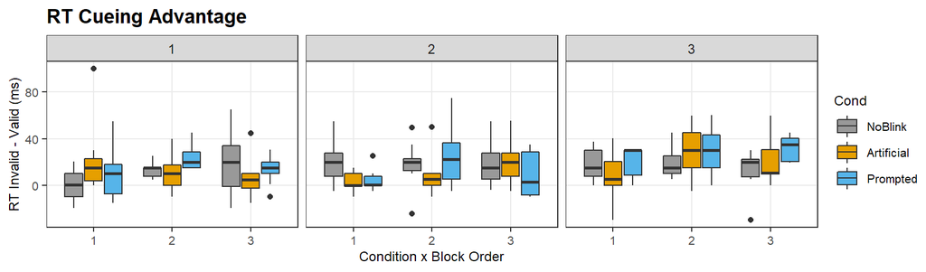

```r
ctoa_valid = ddply(ss_corr[ss_corr$CueValid=='Valid',], .(block_order, cond_order, Cond, subj),
                   summarise, RT=median(RT))
ctoa_invalid = ddply(ss_corr[ss_corr$CueValid=='Invalid',], .(block_order, cond_order, Cond, subj),
                     summarise, RT=median(RT))
ctoa_adv = merge(ctoa_valid, ctoa_invalid, by=c('block_order', 'cond_order', 'Cond', 'subj'))
ctoa_adv$RT = ctoa_adv$RT.y - ctoa_adv$RT.x  # Invalid - Valid RT
p = ggplot(data=ctoa_adv, aes(x=factor(block_order), y=RT, fill=Cond)) +
    geom_boxplot() + xlab('Condition x Block Order') + ylab('RT Invalid - Valid (ms)') +
    facet_wrap(~cond_order) +
    theme(panel.grid.minor=element_blank(), plot.title = element_text(hjust = 0.5)) +
    ggtitle('RT Cueing Advantage') + guides(alpha=F)
p = plot_themefy(p)
print(p)
```

```r
print(lmerfn(lmer(RT ~ cue_valid * Cond * ctoa_0 + cond_order + block + (1|subj), data = ds_rt)))
```

```
##                                    estm    se       df   tVal  pVal star num
## (Intercept)                     339.855 6.926   40.250 49.067 0.000  ***   0
## cue_valid                       -17.568 3.317 8909.035 -5.297 0.000   **   1
## CondArtificial                   11.935 4.121 8909.152  2.896 0.004    *   2
## CondPrompted                      7.299 4.110 8909.101  1.776 0.076        3
## ctoa_0                           -3.604 4.481 8909.185 -0.804 0.421        4
## cond_order                       -3.418 0.657 8909.783 -5.203 0.000   **   5
## block                            -3.969 0.653 8909.185 -6.080 0.000   **   6
## cue_valid:CondArtificial          4.590 4.746 8909.061  0.967 0.334        7
## cue_valid:CondPrompted           -4.572 4.731 8909.047 -0.966 0.334        8
## cue_valid:ctoa_0                  5.514 5.163 8909.047  1.068 0.285        9
## CondArtificial:ctoa_0            -2.467 6.385 8909.208 -0.386 0.699       10
## CondPrompted:ctoa_0               5.275 6.377 8909.161  0.827 0.408       11
## cue_valid:CondArtificial:ctoa_0  -8.280 7.350 8909.042 -1.127 0.260       12
## cue_valid:CondPrompted:ctoa_0     1.974 7.347 8909.074  0.269 0.788       13
```

# 3 Eye blinks

There are several events taking place: blink cue (cue_delay), spatial cue (scue_delay), blink onset and offset (leading to blink duration), target appearance (CTOA), and subject response (RT). These also yield the blink onset relative to the blink cue (blink latency) and relative to the spatial cue (CBOA = cue-blink onset asynchrony, which may be negative).

Longer RTs are associated with longer blinks, but only for later targets. This may hint at the effects of fatigue.

Longer RTs are also associated with /later/ blinks, although the effect is reduced for later targets. Blink latency may be indicative of the individual differences in reaction times. After all, RTs should be similar to targets and blink cues.

Neither effect seems to have anything to do with spatial cue validity: although all analyses pick up the cue validity effect, none of the blink conditions seem to interact with it. That means that blinking does not seem to affect spatial attentional allocation based on an audio spatial cue.

## 3.1 Blink durations

```r
dsa$bdur = dsa$tot_blank_time
bdur_sumss = ddply(dsa, .(Cond, subj), summarize,
                        bdur_ave = mean(bdur),
                        bdur_sd = sd(bdur))
dsa = merge(dsa, bdur_sumss, by=c('Cond', 'subj'))
dsa$bdur_z = with(dsa, (bdur - bdur_ave) / bdur_sd)
dsa$bdur_c = with(dsa, (bdur - mean(bdur)))
dsa$ctoa_0 = (dsa$targ_soa - 0.3) * 5  # [0.3, 0.4, 0.5] -> [0, 0.1, 0.2] -> [0, 0.5, 1]
```

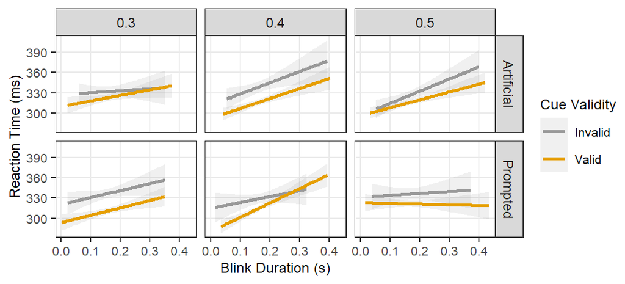

```r
p = ggplot(dsa, aes(x=bdur, y=RT, color=CueValid)) +
    stat_smooth(method='lm', alpha=0.15) +
    facet_grid(Cond~targ_soa) + guides(color=guide_legend(title='Cue Validity')) +
    xlab('Blink Duration (s)') + ylab('Reaction Time (ms)')
p = plot_themefy(p)
plot(p)
```

```r
# print(lmerfn(lmer(RT ~ cue_valid * Cond * ctoa_0 * bdur + block + (1|subj), data = dsa)))
```

Note: Important to center blink duration: otherwise, the model picks up the effects of asynchronies (#3,8) at meaningless blink duration of zero. Trying with a centered, non-normalized blink duration:

```r
print(lmerfn(lmer(RT ~ cue_valid * Cond * ctoa_0 * bdur_c + block + (1|subj), data = dsa)))
```

```
##                                          estm      se       df   tVal  pVal star num
## (Intercept)                           345.907   7.280   37.730 47.512 0.000  ***   0
## cue_valid                             -13.033   3.583 5917.011 -3.638 0.000    *   1
## CondPrompted                           -3.462   4.395 5917.534 -0.788 0.431        2
## ctoa_0                                 -6.292   4.766 5917.164 -1.320 0.187        3
## bdur_c                                -82.582  54.221 5934.428 -1.523 0.128        4
## block                                  -5.089   0.852 5918.693 -5.973 0.000   **   5
## cue_valid:CondPrompted                 -8.924   5.057 5917.056 -1.765 0.078        6
## cue_valid:ctoa_0                       -1.290   5.493 5917.009 -0.235 0.814        7
## CondPrompted:ctoa_0                     7.320   6.760 5917.335  1.083 0.279        8
## cue_valid:bdur_c                       51.036  59.701 5917.347  0.855 0.393        9
## CondPrompted:bdur_c                    19.409  74.183 5919.072  0.262 0.794       10
## ctoa_0:bdur_c                         166.765  76.105 5917.256  2.191 0.028    *  11
## cue_valid:CondPrompted:ctoa_0           9.858   7.781 5917.028  1.267 0.205       12
## cue_valid:CondPrompted:bdur_c          10.312  84.270 5917.221  0.122 0.903       13
## cue_valid:ctoa_0:bdur_c              -144.698  87.470 5917.291 -1.654 0.098       14
## CondPrompted:ctoa_0:bdur_c           -185.737 107.714 5917.435 -1.724 0.085       15
## cue_valid:CondPrompted:ctoa_0:bdur_c  101.509 123.868 5917.182  0.819 0.413       16
```

This model picks up the cue validity effect (#1), but this effect does not interact with the blink condition effects.

Another (barely significant) effect is the interaction between the asynchrony and blink durations: longer blink durations increase RT, but only to later targets (#11). In other words, for later targets, an increase of 100 ms in blink durations leads to ~16.7 ms slowdown in RT.

## 3.2 Blink latencies

```r
dsa$blat = dsa$blank_time_beg - (dsa$cue_time - dsa$trial_time_beg)
blat_sumss = ddply(dsa, .(Cond, subj), summarize,
                        blat_ave = mean(blat),
                        blat_sd = sd(blat))
dsa = merge(dsa, blat_sumss, by=c('Cond', 'subj'))
dsa$blat_c = with(dsa, (blat - mean(blat)))
dsa$blat_z = with(dsa, (blat - blat_ave) / blat_sd)
```

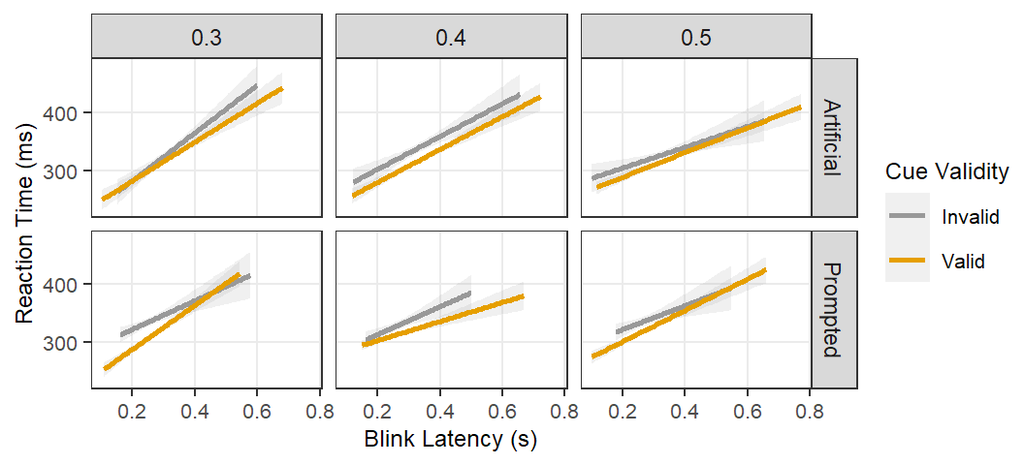

```r
p = ggplot(dsa, aes(x=blat, y=RT, color=CueValid)) +
    stat_smooth(method='lm', alpha=0.15) +
    facet_grid(Cond~targ_soa) + guides(color=guide_legend(title='Cue Validity')) +
    xlab('Blink Latency (s)') + ylab('Reaction Time (ms)')
p = plot_themefy(p)
plot(p)
```

```r
lmerfn(lmer(RT ~ cue_valid * Cond * ctoa_0 * blat_c + block + (1|subj), data = dsa))
```

|  | estm | se | df | tVal | pVal | star | num |
| --- | --- | --- | --- | --- | --- | --- | --- |
| (Intercept) | 337.219 | 6.846 | 45.136 | 49.260 | 0.000 | *** | 0 |
| cue_valid | -12.540 | 3.840 | 5917.195 | -3.266 | 0.001 | * | 1 |
| CondPrompted | 11.142 | 5.003 | 5918.802 | 2.227 | 0.026 | * | 2 |
| ctoa_0 | -2.179 | 5.068 | 5917.246 | -0.430 | 0.667 |  | 3 |
| blat_c | 282.883 | 51.949 | 5920.572 | 5.445 | 0.000 | ** | 4 |
| block | -4.483 | 0.844 | 5917.546 | -5.313 | 0.000 | ** | 5 |
| cue_valid:CondPrompted | -8.787 | 5.705 | 5917.179 | -1.540 | 0.124 |  | 6 |
| cue_valid:ctoa_0 | -3.139 | 5.860 | 5917.199 | -0.536 | 0.592 |  | 7 |
| CondPrompted:ctoa_0 | -0.747 | 7.485 | 5917.278 | -0.100 | 0.921 |  | 8 |
| cue_valid:blat_c | -36.058 | 58.229 | 5917.411 | -0.619 | 0.536 |  | 9 |
| CondPrompted:blat_c | -115.261 | 75.427 | 5918.523 | -1.528 | 0.127 |  | 10 |
| ctoa_0:blat_c | -171.198 | 77.232 | 5917.660 | -2.217 | 0.027 | * | 11 |
| cue_valid:CondPrompted:ctoa_0 | 10.943 | 8.563 | 5917.153 | 1.278 | 0.201 |  | 12 |
| cue_valid:CondPrompted:blat_c | 85.915 | 85.264 | 5917.513 | 1.008 | 0.314 |  | 13 |
| cue_valid:ctoa_0:blat_c | 59.394 | 86.806 | 5917.449 | 0.684 | 0.494 |  | 14 |
| CondPrompted:ctoa_0:blat_c | 135.932 | 111.866 | 5917.740 | 1.215 | 0.224 |  | 15 |
| cue_valid:CondPrompted:ctoa_0:blat_c | -73.187 | 125.389 | 5917.573 | -0.584 | 0.559 |  | 16 |

This model picks up the cue validity effect (#1).

Oddly, it also says that, when both artificial and real blink latencies are centered, the real blinks are associated with slightly longer reaction times. This suggests that, in the the simple model, the mean of blink latencies is not the same as here. Might have something to do with the fact that, here, the no-blink condition is not analyzed.

Unlike with blink durations, blink latencies are generally associated with a robust effect on RT: later blinks are associated with much slower reaction times (#4). For later targets, this effect is significantly reduced (#11).